# HW4

Ali Ozan Memetoğlu

1/25/2021

# Stationarity of Turkish Electricity Consumption Data

## Manipulation

```r
require(data.table)
require(lubridate)
require(ggplot2)
require(urca)
require(stats)
require(forecast)
dt = fread('RealTimeConsumption-01012017-22012021.csv')
str(dt)
```

```
## Classes 'data.table' and 'data.frame':   35592 obs. of  3 variables:
##  $ Date             : chr  "01.01.2017" "01.01.2017" "01.01.2017" "01.01.2017" ...
##  $ Hour             : chr  "00:00" "01:00" "02:00" "03:00" ...
##  $ Consumption (MWh): chr  "27,223.06" "25,825.90" "24,252.68" "22,915.47" ...
##  - attr(*, ".internal.selfref")=<externalptr>
```

The structure of the data is not really good, we should convert char type date hour to a better format like timestamp and char type consumption to a numeric type.

```r
dt[,Date:=as.Date(Date,"%d.%m.%Y")]
dt[,timestamp := ymd_hm(paste(Date, Hour))]
dt[,Hour := NULL]
setnames(dt, 'Consumption (MWh)', 'Consumption')
dt[,Consumption:=as.double(gsub(",", "",Consumption))]
```

Since making predictions on an hourly basis is difficult and it is hard to capture hourly fluctuations and those fluctuations might affect our model, we will use daily mean comsumption values.

## Analysis

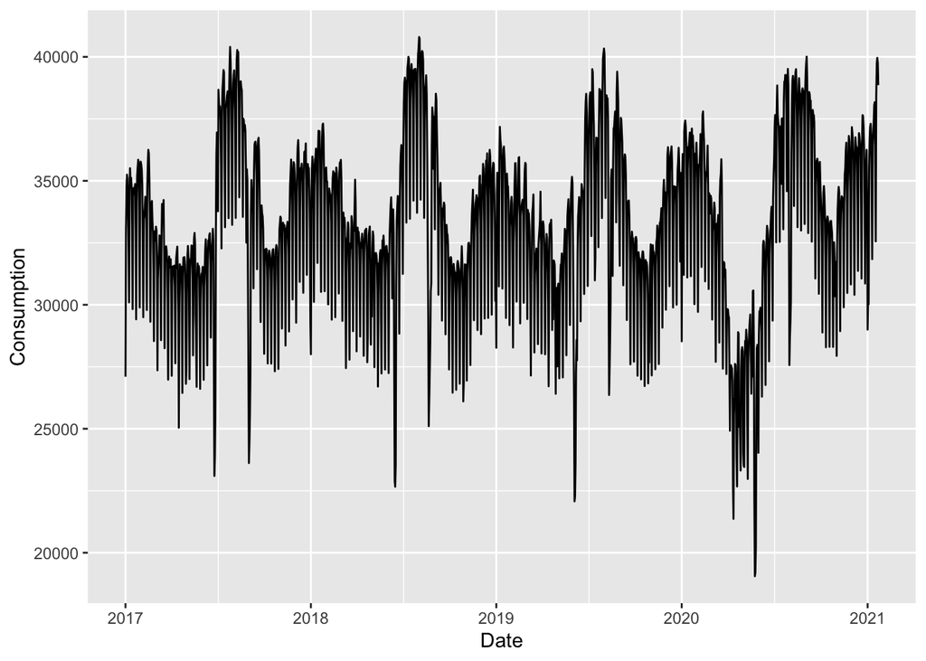

```r
daily_mean_consuption = dt[,.(Consumption = mean(Consumption)),by=.(Date)]
daily_mean_consuption_train <- daily_mean_consuption[Date < as.Date('2021-01-09')]
daily_mean_consuption_valid <- daily_mean_consuption[Date >= as.Date('2021-01-09')]

ggplot(data = daily_mean_consuption, aes(x = Date, y = Consumption)) + geom_line()
```

Although there is no significant trend, we can observe the yearly seasonality. We don’t really need to do any BoxCox or log transformation because although mean is changing variation seems to be constant.

```r
summary(ur.kpss(daily_mean_consuption$Consumption))
```

```
##
## #######################
## # KPSS Unit Root Test #
## #######################
##
## Test is of type: mu with 7 lags.
##
## Value of test-statistic is: 0.1777
##
## Critical value for a significance level of:
##                 10pct  5pct 2.5pct  1pct
## critical values 0.347 0.463  0.574 0.739
```

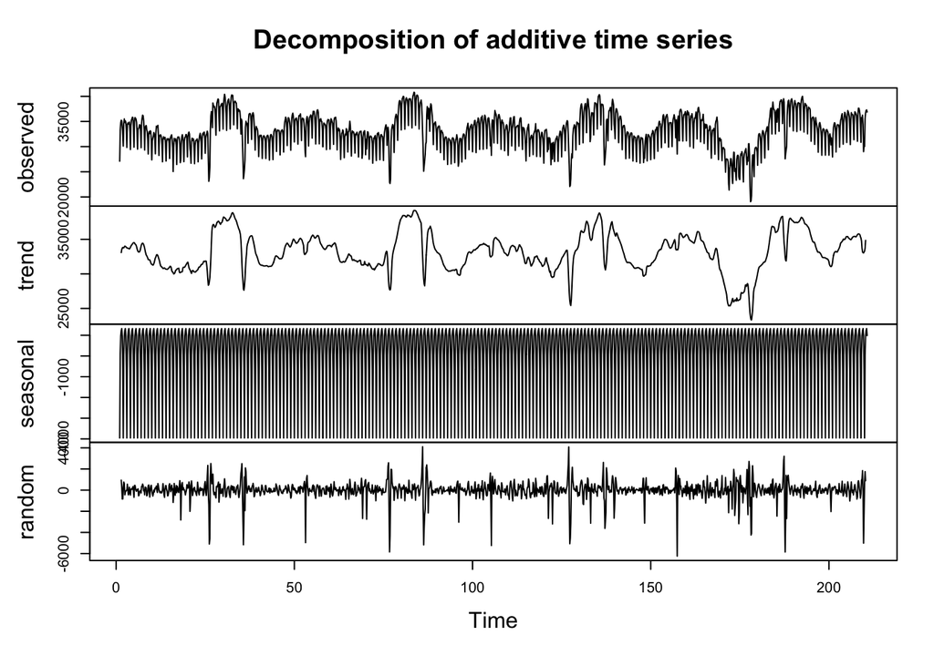

```r
mean_consumption = ts(daily_mean_consuption_train$Consumption, freq = 7)
ts_decomposed = decompose(mean_consumption)
plot(ts_decomposed)
```

Apparently outliers deteriorate the random series left, so we can build a simple model to find outliers then impute a reasonable value such as the value from last week so that we will left with more stationary residuals.

**Outlier Analysis:**

```r
daily_mean_consuption_train[,wok:=as.factor(weekdays(Date))]
daily_mean_consuption_train[,month:=as.factor(month(Date))]
daily_mean_consuption_train[,trend:=1:.N]
fit_outlier = lm(Consumption ~ wok + month + trend,daily_mean_consuption_train)
summary(fit_outlier)
```

```
##
## Call:
## lm(formula = Consumption ~ wok + month + trend, data = daily_mean_consuption_train)
##
## Residuals:
##      Min       1Q   Median       3Q      Max
## -12131.5   -714.8    242.4   1172.2   5621.9
##
## Coefficients:
##                Estimate Std. Error t value Pr(>|t|)
## (Intercept)   3.543e+04  2.337e+02 151.634  < 2e-16 ***
## wokMonday    -9.398e+02  1.986e+02  -4.733 2.43e-06 ***
## wokSaturday  -1.656e+03  1.988e+02  -8.330  < 2e-16 ***
## wokSunday    -4.980e+03  1.986e+02 -25.082  < 2e-16 ***
## wokThursday   3.385e+02  1.985e+02   1.705   0.0884 .
## wokTuesday   -1.190e+01  1.986e+02  -0.060   0.9522
## wokWednesday  2.253e+02  1.986e+02   1.134   0.2568
## month2       -4.097e+02  2.608e+02  -1.571   0.1163
## month3       -2.367e+03  2.544e+02  -9.303  < 2e-16 ***
## month4       -4.318e+03  2.567e+02 -16.823  < 2e-16 ***
## month5       -4.432e+03  2.546e+02 -17.412  < 2e-16 ***
## month6       -2.823e+03  2.569e+02 -10.990  < 2e-16 ***
## month7        2.818e+03  2.549e+02  11.053  < 2e-16 ***
## month8        1.856e+03  2.552e+02   7.272 5.77e-13 ***
## month9       -1.970e+02  2.578e+02  -0.764   0.4448
## month10      -3.247e+03  2.560e+02 -12.685  < 2e-16 ***
## month11      -1.506e+03  2.586e+02  -5.825 7.01e-09 ***
## month12       1.609e+02  2.570e+02   0.626   0.5314
## trend        -6.562e-02  1.287e-01  -0.510   0.6101
## ---
## Signif. codes:  0 '***' 0.001 '**' 0.01 '*' 0.05 '.' 0.1 ' ' 1
##
## Residual standard error: 2034 on 1450 degrees of freedom
## Multiple R-squared:  0.6618, Adjusted R-squared:  0.6576
## F-statistic: 157.6 on 18 and 1450 DF,  p-value: < 2.2e-16
```

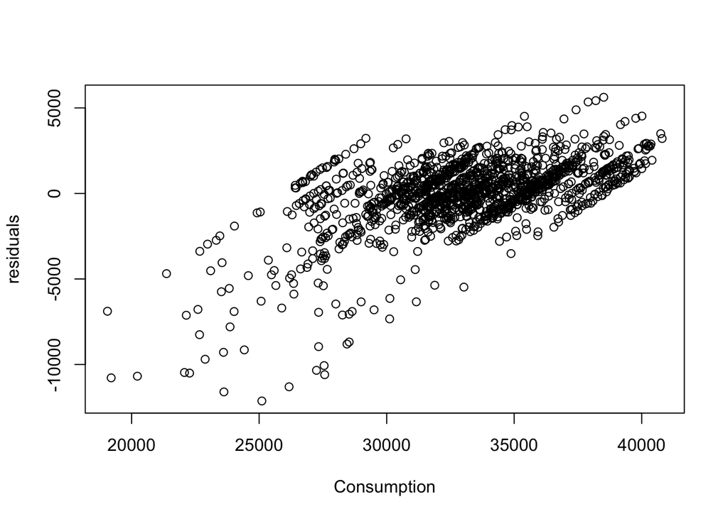

```r
plot(daily_mean_consuption_train[,.(Consumption, residuals= residuals(fit_outlier))])
```

Apparently it would be better if we fit a autoregressive model to find outliers.

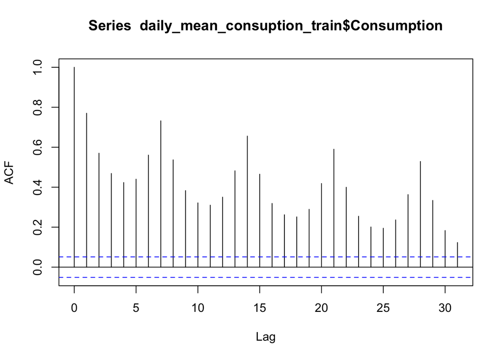

```r
acf(daily_mean_consuption_train$Consumption)
```

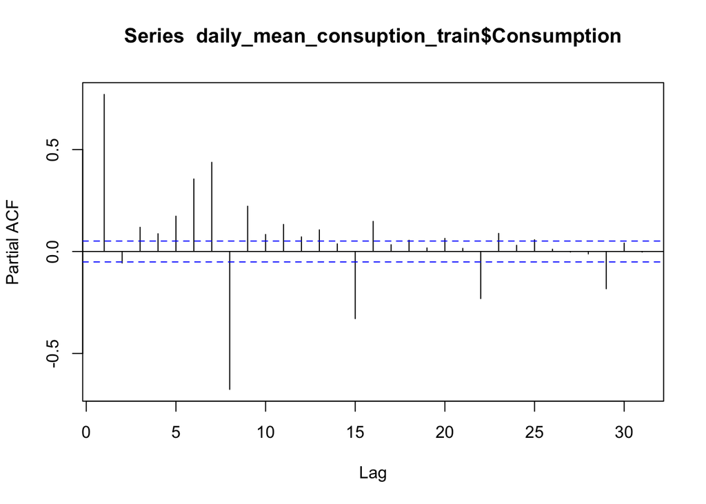

```r
pacf(daily_mean_consuption_train$Consumption)
```

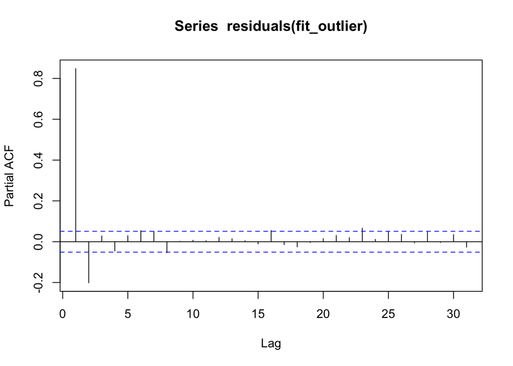

```r
pacf(residuals(fit_outlier))
```

A model with lag 1, 2 and 7 might work fine

```r
daily_mean_consuption_train[,lag_1:=shift(Consumption,1)]
daily_mean_consuption_train[,lag_2:=shift(Consumption,2)]
daily_mean_consuption_train[,lag_7:=shift(Consumption,7)]

fit_outlier_2 = lm(Consumption ~ wok + month + lag_1 + lag_2+ lag_7,daily_mean_consuption_train)
summary(fit_outlier_2)
```

```
##
## Call:
## lm(formula = Consumption ~ wok + month + lag_1 + lag_2 + lag_7,
##     data = daily_mean_consuption_train)
##
## Residuals:
##     Min      1Q  Median      3Q     Max
## -7054.5  -291.7    18.5   365.3  6540.2
##
## Coefficients:
##                Estimate Std. Error t value Pr(>|t|)
## (Intercept)   4.525e+03  5.745e+02   7.876 6.58e-15 ***
## wokMonday     4.307e+03  1.370e+02  31.425  < 2e-16 ***
## wokSaturday  -1.188e+03  1.000e+02 -11.880  < 2e-16 ***
## wokSunday    -2.700e+03  1.253e+02 -21.537  < 2e-16 ***
## wokThursday   3.669e+02  9.705e+01   3.781 0.000163 ***
## wokTuesday    6.210e+01  1.465e+02   0.424 0.671641
## wokWednesday  3.116e+02  9.973e+01   3.125 0.001814 **
## month2       -1.448e+02  1.285e+02  -1.127 0.259990
## month3       -4.693e+02  1.297e+02  -3.618 0.000307 ***
## month4       -6.995e+02  1.422e+02  -4.919 9.69e-07 ***
## month5       -6.465e+02  1.438e+02  -4.495 7.52e-06 ***
## month6       -3.393e+02  1.370e+02  -2.477 0.013355 *
## month7        3.407e+02  1.314e+02   2.594 0.009589 **
## month8        1.315e+02  1.298e+02   1.013 0.311417
## month9       -1.699e+02  1.267e+02  -1.341 0.180152
## month10      -5.464e+02  1.342e+02  -4.073 4.90e-05 ***
## month11      -1.882e+02  1.305e+02  -1.443 0.149313
## month12      -1.080e+02  1.255e+02  -0.861 0.389480
## lag_1         1.067e+00  2.561e-02  41.658  < 2e-16 ***
## lag_2        -2.423e-01  2.618e-02  -9.255  < 2e-16 ***
## lag_7         4.110e-02  1.331e-02   3.088 0.002054 **
## ---
## Signif. codes:  0 '***' 0.001 '**' 0.01 '*' 0.05 '.' 0.1 ' ' 1
##
## Residual standard error: 989.4 on 1441 degrees of freedom
##   (7 observations deleted due to missingness)
## Multiple R-squared:  0.9203, Adjusted R-squared:  0.9192
## F-statistic: 831.7 on 20 and 1441 DF,  p-value: < 2.2e-16
```

```r
daily_mean_consuption_train[,residual_armodel:=c(NA,NA,NA,NA,NA,NA,NA,fit_outlier_2$residuals)]
# Due to the fact we have lag_7, first 7 predictions will be NUll.
daily_mean_consuption_train[,quant5:=quantile(residual_armodel,0.05, na.rm = TRUE)]
daily_mean_consuption_train[,quant95:=quantile(residual_armodel,0.95, na.rm = TRUE)]
daily_mean_consuption_train[residual_armodel>quant95]
```

```
##           Date Consumption       wok month trend    lag_1    lag_2    lag_7
##  1: 2017-05-02    31001.28   Tuesday     5   122 27511.07 26813.76 31904.92
##  2: 2017-05-20    28760.69  Saturday     5   140 29563.23 32481.97 31389.78
##  3: 2017-06-28    33175.06 Wednesday     6   179 25886.96 23859.14 32584.07
##  4: 2017-07-02    33772.02    Sunday     7   183 36090.19 36951.25 23098.24
##  5: 2017-07-03    38672.33    Monday     7   184 33772.02 36090.19 23859.14
##  6: 2017-08-07    38559.76    Monday     8   219 33505.86 36870.60 37914.00
##  7: 2017-09-02    24418.67  Saturday     9   245 23619.08 27547.64 35616.94
##  8: 2017-09-03    25483.63    Sunday     9   246 24418.67 23619.08 32508.03
##  9: 2017-09-05    33846.83   Tuesday     9   248 27332.09 25483.63 35055.15
## 10: 2018-01-02    33803.15   Tuesday     1   367 28005.32 29245.16 35679.73
## 11: 2018-03-22    33576.85  Thursday     3   446 32287.90 32481.39 33324.01
## 12: 2018-03-29    35048.19  Thursday     3   453 33839.31 33013.89 33576.85
## 13: 2018-04-24    31936.79   Tuesday     4   479 28687.35 27683.76 32882.79
## 14: 2018-05-02    32284.30 Wednesday     5   487 29526.73 31455.76 32833.51
```

[output cut: 137 more lines]

```r
daily_mean_consuption_train[,outlier_large:= as.numeric(residual_armodel>quant95)]
daily_mean_consuption_train[,outlier_small:= as.numeric(residual_armodel<quant5)]
```

To interpolate those days, I will use the last weeks value, altough this might not be reasonable to some extent due to the fact that there might be some consecutive outlier weekdays. So we will go twice week back for those days.

```r
special_days = daily_mean_consuption_train[outlier_large == 1 | outlier_small == 1 , Date]

normal_outlier_days = daily_mean_consuption_train[Date %in% (special_days - 7) & outlier_large != 1 & outlier_small != 1, Date+7 ]
double_outlier_days = daily_mean_consuption_train[Date %in% (special_days - 7) & (outlier_large == 1 | outlier_small == 1), Date+7  ]

daily_mean_consuption_train[Date %in% normal_outlier_days, Consumption:=(daily_mean_consuption_train[Date %in% (normal_outlier_days-7), Consumption]) ]
daily_mean_consuption_train[Date %in% double_outlier_days, Consumption:=(daily_mean_consuption_train[Date %in% (double_outlier_days-14), Consumption]) ]

daily_mean_consuption[Date %in% normal_outlier_days, Consumption:=(daily_mean_consuption[Date %in% (normal_outlier_days-7), Consumption]) ]
daily_mean_consuption[Date %in% double_outlier_days, Consumption:=(daily_mean_consuption[Date %in% (double_outlier_days-14), Consumption]) ]
```

We can try decomposition now.

**Decomposition**

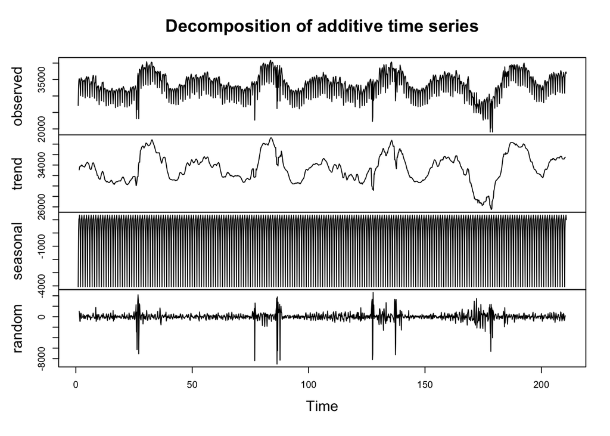

```r
mean_consumption_ts = ts(daily_mean_consuption_train$Consumption, freq = 7)
ts_decomposed = decompose(mean_consumption_ts)
plot(ts_decomposed)
```

Although there are still some outliers, new random series is definitely better than the previous one.

```r
print(ndiffs(mean_consumption_ts))
```

```
## [1] 0
```

```r
print(nsdiffs(mean_consumption_ts))
```

```
## [1] 1
```

We need one seasonal differencing.

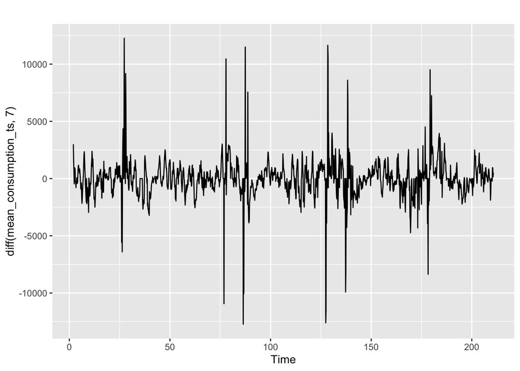

```r
autoplot(diff(mean_consumption_ts, 7))
```

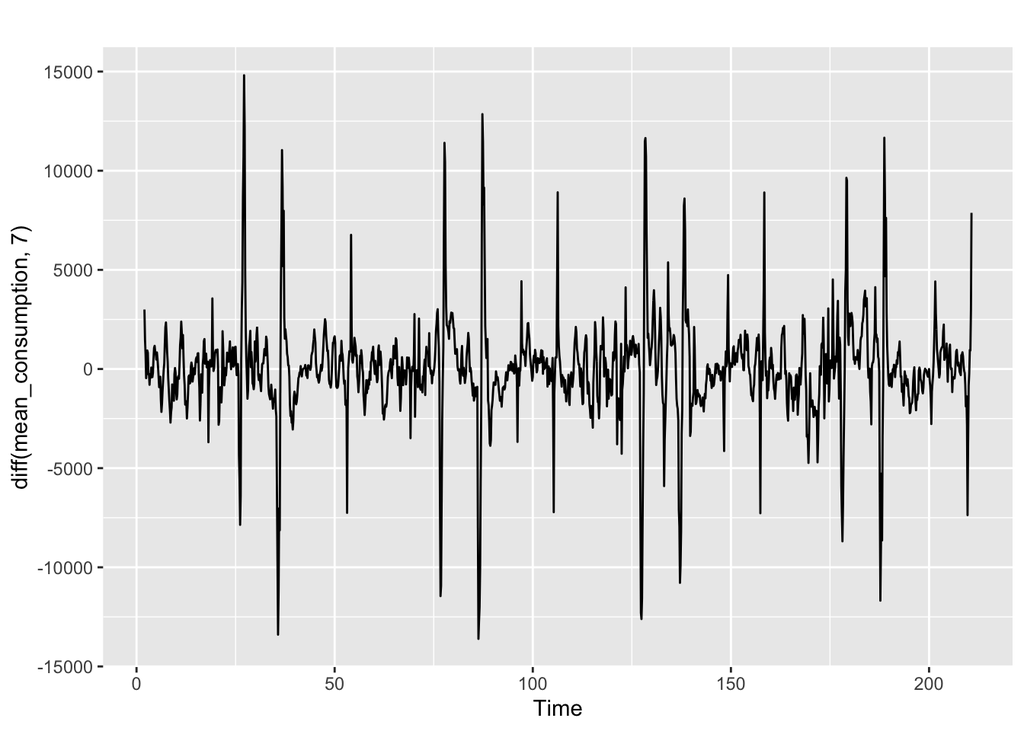

```r
autoplot(diff(mean_consumption, 7))
```

Although we managed to remove most of them, there are still some outliers remaining. But we can be content with the one we achieved so far.

```r
summary(ur.kpss(diff(mean_consumption_ts, 7)))
```

```
##
## #######################
## # KPSS Unit Root Test #
## #######################
##
## Test is of type: mu with 7 lags.
##
## Value of test-statistic is: 0.0309
##
## Critical value for a significance level of:
##                 10pct  5pct 2.5pct  1pct
## critical values 0.347 0.463  0.574 0.739
```

It does not really matter if we take the difference now, because we can take the difference while building the ARIMA model.

```r
random = ts_decomposed$random
model_1 = auto.arima(random)
auto.arima(random, trace = TRUE)
```

```
##
##  Fitting models using approximations to speed things up...
##
##  ARIMA(2,0,2)(1,0,1)[7] with non-zero mean : Inf
##  ARIMA(0,0,0)           with non-zero mean : 24127.19
##  ARIMA(1,0,0)(1,0,0)[7] with non-zero mean : 24093.61
##  ARIMA(0,0,1)(0,0,1)[7] with non-zero mean : 24085.47
##  ARIMA(0,0,0)           with zero mean     : 24125.18
##  ARIMA(0,0,1)           with non-zero mean : 24120.75
##  ARIMA(0,0,1)(1,0,1)[7] with non-zero mean : 24089.2
##  ARIMA(0,0,1)(0,0,2)[7] with non-zero mean : 24086.58
##  ARIMA(0,0,1)(1,0,0)[7] with non-zero mean : 24087.47
##  ARIMA(0,0,1)(1,0,2)[7] with non-zero mean : 24090.7
##  ARIMA(0,0,0)(0,0,1)[7] with non-zero mean : 24093.06
##  ARIMA(1,0,1)(0,0,1)[7] with non-zero mean : 23671.43
##  ARIMA(1,0,1)           with non-zero mean : 23708.79
##  ARIMA(1,0,1)(1,0,1)[7] with non-zero mean : Inf
##  ARIMA(1,0,1)(0,0,2)[7] with non-zero mean : 23671.83
##  ARIMA(1,0,1)(1,0,0)[7] with non-zero mean : Inf
##  ARIMA(1,0,1)(1,0,2)[7] with non-zero mean : Inf
##  ARIMA(1,0,0)(0,0,1)[7] with non-zero mean : 24090.01
##  ARIMA(2,0,1)(0,0,1)[7] with non-zero mean : Inf
##  ARIMA(1,0,2)(0,0,1)[7] with non-zero mean : Inf
##  ARIMA(0,0,2)(0,0,1)[7] with non-zero mean : 23619.26
##  ARIMA(0,0,2)           with non-zero mean : 23661.44
##  ARIMA(0,0,2)(1,0,1)[7] with non-zero mean : Inf
##  ARIMA(0,0,2)(0,0,2)[7] with non-zero mean : 23620.89
##  ARIMA(0,0,2)(1,0,0)[7] with non-zero mean : 23627.25
##  ARIMA(0,0,2)(1,0,2)[7] with non-zero mean : Inf
##  ARIMA(0,0,3)(0,0,1)[7] with non-zero mean : Inf
##  ARIMA(1,0,3)(0,0,1)[7] with non-zero mean : Inf
##  ARIMA(0,0,2)(0,0,1)[7] with zero mean     : 23617.56
##  ARIMA(0,0,2)           with zero mean     : 23659.66
##  ARIMA(0,0,2)(1,0,1)[7] with zero mean     : Inf
##  ARIMA(0,0,2)(0,0,2)[7] with zero mean     : 23619.19
##  ARIMA(0,0,2)(1,0,0)[7] with zero mean     : 23625.74
##  ARIMA(0,0,2)(1,0,2)[7] with zero mean     : Inf
##  ARIMA(0,0,1)(0,0,1)[7] with zero mean     : 24083.46
##  ARIMA(1,0,2)(0,0,1)[7] with zero mean     : Inf
##  ARIMA(0,0,3)(0,0,1)[7] with zero mean     : Inf
##  ARIMA(1,0,1)(0,0,1)[7] with zero mean     : 23669.93
##  ARIMA(1,0,3)(0,0,1)[7] with zero mean     : Inf
##
##  Now re-fitting the best model(s) without approximations...
##
##  ARIMA(0,0,2)(0,0,1)[7] with zero mean     : Inf
##  ARIMA(0,0,2)(0,0,2)[7] with zero mean     : Inf
##  ARIMA(0,0,2)(0,0,1)[7] with non-zero mean : Inf
##  ARIMA(0,0,2)(0,0,2)[7] with non-zero mean : Inf
##  ARIMA(0,0,2)(1,0,0)[7] with zero mean     : Inf
##  ARIMA(0,0,2)(1,0,0)[7] with non-zero mean : Inf
##  ARIMA(0,0,2)           with zero mean     : Inf
##  ARIMA(0,0,2)           with non-zero mean : Inf
##  ARIMA(1,0,1)(0,0,1)[7] with zero mean     : Inf
##  ARIMA(1,0,1)(0,0,1)[7] with non-zero mean : Inf
##  ARIMA(1,0,1)(0,0,2)[7] with non-zero mean : Inf
##  ARIMA(1,0,1)           with non-zero mean : Inf
##  ARIMA(0,0,1)(0,0,1)[7] with zero mean     : 24083.54
##
##  Best model: ARIMA(0,0,1)(0,0,1)[7] with zero mean
```

```
## Series: random
## ARIMA(0,0,1)(0,0,1)[7] with zero mean
##
## Coefficients:
##           ma1    sma1
##       -0.1303  0.1572
## s.e.   0.0473  0.0251
##
## sigma^2 estimated as 823237:  log likelihood=-12038.76
## AIC=24083.53   AICc=24083.54   BIC=24099.39
```

```r
trend= as.numeric(rep(tail(ts_decomposed$trend[!is.na(ts_decomposed$trend)],1), 14))
season= as.numeric(tail(ts_decomposed$seasonal, 14))

results_1 = predict(model_1, n.ahead = 14)$pred + trend + season

daily_mean_consuption_valid[,arima_1 := results_1]

accu = function(actual, forecast){
  n = length(actual)
  error = actual - forecast
  mean = mean(actual)
  sd = sd(actual)
  FBias = sum(error)/sum(actual)
  MPE = sum(error/actual)/n
  MAPE = sum(abs(error/actual))/n
  RMSE = sqrt(sum(error^2)/n)
  MAD = sum(abs(error))/n
  WMAPE = MAD/mean
  return(data.frame(n,sd,FBias,MPE,MAPE,RMSE,MAD,WMAPE))
}

daily_mean_consuption_valid[,accu(Consumption, arima_1)]
```

```
##    n       sd      FBias        MPE       MAPE    RMSE      MAD      WMAPE
## 1 14 2564.411 0.04217104 0.04084506 0.04090038 1916.09 1564.035 0.04222299
```

In performance measure, it is better to compare WMAPE in our electricity consumption data because consumption ranges between large and small values. It is not really reasonable to penalize the model when it is low actual values as it is the case in MAPE.

```r
#Sliding window model

test_start = as.Date('2021-01-09')
daily_report = data.frame(n = as.numeric(),sd= as.numeric(),FBias= as.numeric(),MPE= as.numeric(),MAPE= as.numeric(),RMSE= as.numeric(),MAD= as.numeric(),WMAPE= as.numeric())
results = vector('list', 14)

for(i in 0:13){

  current_test_date = test_start + i
  train_data = daily_mean_consuption[Date < current_test_date]
  rand = decompose(ts(train_data$Consumption, freq = 7))$random
  fitday = auto.arima(rand)
  results[i+1] = as.numeric(predict(fitday, n.ahead = 1)$pred)
  daily_report = rbind(daily_report,accu(daily_mean_consuption_valid[i+1,Consumption],as.numeric(predict(fitday, n.ahead = 1)$pred + trend[1]+season[i+1])))
}
daily_report
```

```
##    n sd         FBias           MPE         MAPE       RMSE        MAD
## 1  1 NA -0.0003872667 -0.0003872667 0.0003872667   13.46974   13.46974
## 2  1 NA  0.0152534185  0.0152534185 0.0152534185  485.69785  485.69785
## 3  1 NA  0.0220642828  0.0220642828 0.0220642828  803.83410  803.83410
## 4  1 NA  0.0084303803  0.0084303803 0.0084303803  311.06412  311.06412
## 5  1 NA  0.0196454239  0.0196454239 0.0196454239  734.93275  734.93275
## 6  1 NA  0.0315100754  0.0315100754 0.0315100754 1199.14908 1199.14908
## 7  1 NA  0.0442183699  0.0442183699 0.0442183699 1687.83206 1687.83206
## 8  1 NA  0.0236410222  0.0236410222 0.0236410222  843.21251  843.21251
## 9  1 NA  0.0345470048  0.0345470048 0.0345470048 1124.77993 1124.77993
## 10 1 NA  0.0719474363  0.0719474363 0.0719474363 2766.22691 2766.22691
## 11 1 NA  0.0817102185  0.0817102185 0.0817102185 3245.83493 3245.83493
## 12 1 NA  0.0846488724  0.0846488724 0.0846488724 3382.63814 3382.63814
## 13 1 NA  0.0730535136  0.0730535136 0.0730535136 2906.31575 2906.31575
## 14 1 NA  0.0592833171  0.0592833171 0.0592833171 2303.83719 2303.83719
##           WMAPE
## 1  0.0003872667
## 2  0.0152534185
## 3  0.0220642828
## 4  0.0084303803
## 5  0.0196454239
## 6  0.0315100754
## 7  0.0442183699
## 8  0.0236410222
## 9  0.0345470048
## 10 0.0719474363
## 11 0.0817102185
## 12 0.0846488724
## 13 0.0730535136
## 14 0.0592833171
```

Because we have only one variable, sd values are NA. One important remark we can make is that our bias is always positive except the first prediction. So our model is underpredicting.

```r
results_2 = as.numeric(results) + trend + season
daily_mean_consuption_valid[,arima_2_sw := results_2]
daily_mean_consuption_valid[,accu(Consumption, arima_2_sw)]
```

```
##    n       sd      FBias        MPE       MAPE     RMSE      MAD      WMAPE
## 1 14 2564.411 0.04200198 0.04068329 0.04073861 1911.731 1557.773 0.04205393
```

Although the difference is not significant, we came up with a better model. We can also add a naive base model to discuss validation of our models better.

```r
daily_mean_consuption_valid[,naive:= tail(daily_mean_consuption_train$Consumption,14)]
daily_mean_consuption_valid[,accu(Consumption, naive)]
```

```
##    n       sd      FBias        MPE       MAPE     RMSE      MAD      WMAPE
## 1 14 2564.411 0.04640458 0.04576101 0.04576101 1888.409 1718.931 0.04640458
```

# Conclusion

Even though the naive base model is not improved significantly, both ARIMA model with components moving average and seasonal moving average and ARIMA with sliding window on electricity consumption data with seven day frequency worked fine. In order to make the series as stationary as possible, an outlier analysis is performed at first. If the outliers and the reasons of those special days were examined better, the final model could perform significantly better than naive model. The daily bias, daily weighted mean absolute percentage error for each date is reported in ARIMA with sliding window approach. In the end, the performance of naive and the other two ARIMA models are compared with their WMAPE.